# Cálculo de Tasa de ganancia

Estados Unidos

# Tasa de Ganancia de las Grandes Empresas (Corporate)

### CPI

```r
#función para índices

cpi_anual <- read_csv("../data/cpi.csv") %>%
  group_by(Year) %>%
  summarise(cpi = mean(Value)) %>%
  rename(fecha = Year) %>%
  mutate(cpi = generar_indice(serie = cpi,
                              fecha = fecha,
                              fecha_base = 2018))
```

### Ganancia

Ganancia de las corporaciones antes de impuesto (GCAI). Tabla 6.17, A a D. Kliman toma la linea 1. En millones de USD.

Links a los distintos años:

- [1929 a 1947](https://apps.bea.gov/iTable/iTable.cfm?reqid=19&step=3&isuri=1&select_all_years=1&nipa_table_list=240&series=q&first_year=1929&scale=-99&last_year=1948&categories=survey&thetable=x)
- [1948 a 1987](https://apps.bea.gov/iTable/iTable.cfm?reqid=19&step=3&isuri=1&select_all_years=1&nipa_table_list=241&series=q&first_year=1980&scale=-99&last_year=1987&categories=survey&thetable=x)
- [1987 a 2000](https://apps.bea.gov/iTable/iTable.cfm?reqid=19&step=3&isuri=1&select_all_years=1&nipa_table_list=242&series=q&first_year=1993&scale=-99&last_year=2000&categories=survey&thetable=x)
- [1998 a 2018](https://apps.bea.gov/iTable/iTable.cfm?reqid=19&step=3&isuri=1&select_all_years=1&nipa_table_list=243&series=q&first_year=2011&scale=-99&last_year=2018&categories=survey&thetable=x)

```r
corporate_profits_btaxes_1929_1948 <- read_csv("../data/Table 6.17A. Corporate Profits Before Tax by Industry_1929-1948.csv", skip = 4) %>%
  select(-Line) %>%
  rename(sector = X2) %>%
  na.omit(corporate_profits_btaxes_1929_1948)

corporate_profits_btaxes_1948_1987 <- read_csv("../data/Table 6.17B. Corporate Profits Before Tax by Industry_1948-1987.csv", skip = 4) %>%
  select(-Line, -"1948") %>%
  rename(sector = X2) %>%
  na.omit(corporate_profits_btaxes_1948_1987)

corporate_profits_btaxes_1987_2000 <- read_csv("../data/Table 6.17C. Corporate Profits Before Tax by Industry_1987-2000.csv", skip = 4) %>%
  select(-Line, -"1987") %>%
  rename(sector = X2) %>%
  na.omit(corporate_profits_btaxes_1987_2000)

corporate_profits_btaxes_2000_2018 <- read_csv("../data/Table 6.17D. Corporate Profits Before Tax by Industry_2000-2018.csv", skip = 4) %>%
  select(-Line, -"2000") %>%
  rename(sector=X2) %>%
  na.omit(corporate_profits_btaxes_2000_2018)


#Unificación de bases
corporate_profits_unificacion <- corporate_profits_btaxes_1929_1948 %>%
  left_join(corporate_profits_btaxes_1948_1987,by = "sector") %>%
  left_join(corporate_profits_btaxes_1987_2000,by = "sector") %>%
  left_join(corporate_profits_btaxes_2000_2018,by = "sector") %>%
  select(-"1998.y",-"1999.y") %>%
  gather(.,
         key = fecha,
         value = profit_corp,
         2:91)  %>%
  mutate(profit_corp = as.double(profit_corp),  #por qué pasa esta conversion a chr?
         fecha = as.Date(parse_datetime(fecha, format = "%Y")),
         sector = case_when(sector == "Corporate profits before tax" ~ "Corporate",
                            TRUE ~ sector))
corporate_profits_unificacion
```

| sector | fecha | profit_corp |
| --- | --- | --- |
| Corporate | 1929-01-01 | 10911 |
| Domestic industries | 1929-01-01 | 10679 |
| Agriculture, forestry, and fisheries | 1929-01-01 | 11 |
| Farms | 1929-01-01 | 2 |
| Agricultural services, forestry, and fisheries | 1929-01-01 | 9 |
| Mining | 1929-01-01 | 472 |
| Metal mining | 1929-01-01 | 253 |
| Anthracite mining | 1929-01-01 | 10 |
| Bituminous and other soft coal mining1 | 1929-01-01 | 16 |
| Crude petroleum and natural gas | 1929-01-01 | 133 |

[output cut: 6650 more lines]

```r
rm(corporate_profits_btaxes_1929_1948,
   corporate_profits_btaxes_1948_1987,
   corporate_profits_btaxes_1987_2000,
   corporate_profits_btaxes_2000_2018)
```

### [Capital Adelantado](https://apps.bea.gov/iTable/iTable.cfm?reqid=10&step=3&isuri=1&table_list=49&series=q&first_year=2011&allyears=1&tabledisplay=&scale=-99&last_year=2018)

#### Costos Históricos

##### Stock utilizado por [Kliman](http://www.revistaryr.org.ar/index.php/RyR/article/view/87/87)

```r
stock_corp_hc <- read_csv("../data/Table 6.3. Historical-Cost Net Stock of Private Fixed Assets by Industry Group and Legal Form of Organization.csv", skip = 4) %>%
  select(-Line) %>%
  rename(sector = X2) %>%
  na.omit(stock_corp_hc) %>%
  gather(.,
           key = fecha,
         value = stock,
         2:95) %>%
  mutate(stock_hc = stock * 1000,
         fecha = as.Date(parse_datetime(fecha, format = "%Y"))) %>%
  select(fecha, everything(.), -stock)
stock_corp_hc
```

| fecha | sector | stock_hc |
| --- | --- | --- |
| 1925-01-01 | Private fixed assets | 148100 |
| 1925-01-01 | Corporate | 70500 |
| 1925-01-01 | Financial | 2200 |
| 1925-01-01 | Nonfinancial | 68200 |
| 1925-01-01 | Noncorporate | 77600 |
| 1925-01-01 | Sole proprietorships | 18600 |
| 1925-01-01 | Partnerships | 6100 |
| 1925-01-01 | Nonprofit institutions | 5300 |
| 1925-01-01 | Households | 47600 |
| 1925-01-01 | Tax-exempt cooperatives | 0 |

[output cut: 1212 more lines]

#### [Costos corrientes](https://apps.bea.gov/iTable/iTable.cfm?reqid=10&step=3&isuri=1&table_list=49&series=q&first_year=2011&allyears=1&tabledisplay=&scale=-99&last_year=2018)

Stock Neto de los activos privados fijos de las corporaciones a precios corrientes (Tabla 6.1). Mismas características que la serie a precios históricos.

```r
stock_corp_cc  <- read_csv("../data/stock_current_cost.csv",
    skip = 4) %>%
  select(-Line) %>%
  rename(sector = X2) %>%
  na.omit(stock_corp_hc) %>%
  gather(.,
           key = fecha,
         value = stock,
         2:95) %>%
  mutate(stock = stock * 1000,
         fecha = as.Date(parse_datetime(fecha, format = "%Y"))) %>%
  select(fecha, everything(.)) %>%
  rename(sector.x = sector, stock_cc = stock)
stock_corp_cc
```

| fecha | sector.x | stock_cc |
| --- | --- | --- |
| 1925-01-01 | Private fixed assets | 223400 |
| 1925-01-01 | Corporate | 100100 |
| 1925-01-01 | Financial | 3100 |
| 1925-01-01 | Nonfinancial | 97000 |
| 1925-01-01 | Noncorporate | 123200 |
| 1925-01-01 | Sole proprietorships | 26300 |
| 1925-01-01 | Partnerships | 7900 |
| 1925-01-01 | Nonprofit institutions | 8100 |
| 1925-01-01 | Households | 80900 |
| 1925-01-01 | Tax-exempt cooperatives | 0 |

[output cut: 1212 more lines]

### Tasa de Ganancia de las Corporaciones

```r
rop <- stock_corp_hc %>%
  left_join(corporate_profits_unificacion, by = "fecha") %>%
  left_join(stock_corp_cc, by = c("sector.x", "fecha")) %>%
  filter(sector.x == "Corporate",
         sector.y == "Corporate") %>%
  mutate(stock_hc_anio_ant = lag(stock_hc, k = 1),
         stock_cc_anio_ant = lag(stock_cc, k = 1),
          tg_hc = profit_corp / stock_hc_anio_ant * 100,
          tg_cc = profit_corp / stock_cc_anio_ant * 100 ) %>%
  select(fecha, stock_hc, stock_hc_anio_ant, stock_cc, stock_cc_anio_ant,
         profit_corp, tg_cc, tg_hc)
rop
```

| fecha | stock_hc | stock_hc_anio_ant | stock_cc | stock_cc_anio_ant | profit_corp | tg_cc | tg_hc |
| --- | --- | --- | --- | --- | --- | --- | --- |
| 1929-01-01 | 82600 | NA | 106000 | NA | 10911 | NA | NA |
| 1930-01-01 | 84500 | 82600 | 101000 | 106000 | 4559 | 4.3009434 | 5.5193705 |
| 1931-01-01 | 84200 | 84500 | 90700 | 101000 | 562 | 0.5564356 | 0.6650888 |
| 1932-01-01 | 82400 | 84200 | 84700 | 90700 | -1346 | -1.4840132 | -1.5985748 |
| 1933-01-01 | 80600 | 82400 | 85500 | 84700 | 1832 | 2.1629280 | 2.2233010 |
| 1934-01-01 | 79500 | 80600 | 86800 | 85500 | 3215 | 3.7602339 | 3.9888337 |
| 1935-01-01 | 78900 | 79500 | 86300 | 86800 | 4371 | 5.0357143 | 5.4981132 |
| 1936-01-01 | 79300 | 78900 | 94900 | 86300 | 7107 | 8.2352260 | 9.0076046 |
| 1937-01-01 | 81000 | 79300 | 98400 | 94900 | 7629 | 8.0389884 | 9.6204288 |
| 1938-01-01 | 81200 | 81000 | 97200 | 98400 | 4603 | 4.6778455 | 5.6827160 |

[output cut: 78 more lines]

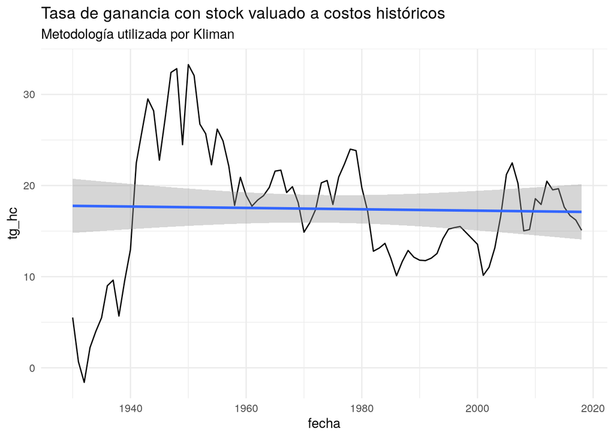

```r
#Gráficos

# Tg de kliman
g1 <- rop %>%
  ggplot(aes(fecha, tg_hc))+
  geom_line()+
  labs(title = "Tasa de ganancia con stock valuado a costos históricos",
       subtitle = "Metodología utilizada por Kliman")+
  geom_smooth(size = 1, linetype = 1, method = "lm", se = TRUE)+
  theme(legend.position = 'none')+
  theme_minimal()
g1
```

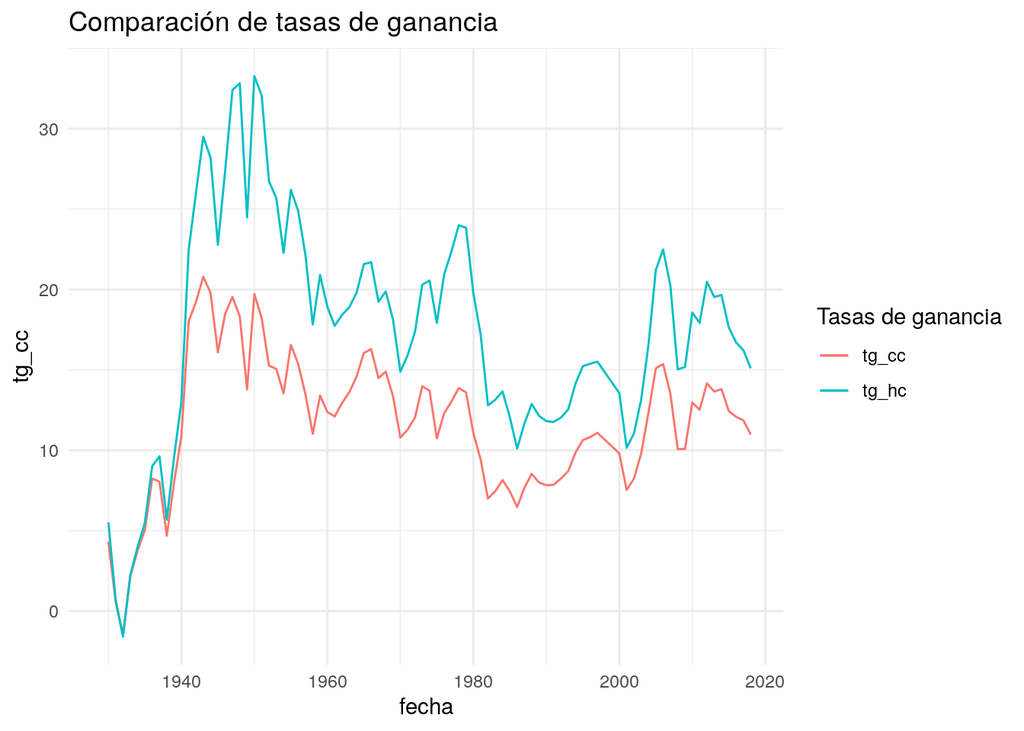

```r
# comparación de tg's
g2 <- rop %>%
    ggplot(aes(fecha, tg_cc, color = "tg_cc"))+
    geom_line()+
    geom_line(aes(fecha, tg_hc, color = "tg_hc"))+
    scale_color_discrete(name = "Tasas de ganancia") + #como modificar este label?
    labs(title = "Comparación de tasas de ganancia") +
    theme_minimal()
g2
```

```r
# ruta_arch <- "comparacion_tg.png"
# png(ruta_arch)
# plot(g2)
# dev.off()

# Resumen tg's
rop %>% select(tg_cc, tg_hc) %>% summary(rop)
```

```
##      tg_cc            tg_hc
##  Min.   :-1.484   Min.   :-1.599
##  1st Qu.: 8.386   1st Qu.:12.941
##  Median :12.102   Median :17.820
##  Mean   :11.703   Mean   :17.445
##  3rd Qu.:14.071   3rd Qu.:21.636
##  Max.   :20.793   Max.   :33.268
##  NA's   :1        NA's   :1
```

#### Tasa de Ganancia sector industrial y farms

```r
#problema para calcularla con el stock del año anterior
rop_rama <- stock_corp_hc %>%
  filter(sector %in% c("Private fixed assets", "Corporate", "Farms", "Manufacturing")) %>%
  left_join(corporate_profits_unificacion, by = c("fecha", "sector")) %>%
  group_by(fecha, sector) %>%
  summarise(tg_1 = profit_corp / stock_hc * 100)
rop_rama
```

| fecha | sector | tg_1 |
| --- | --- | --- |
| 1925-01-01 | Corporate | NA |
| 1925-01-01 | Farms | NA |
| 1925-01-01 | Manufacturing | NA |
| 1925-01-01 | Private fixed assets | NA |
| 1926-01-01 | Corporate | NA |
| 1926-01-01 | Farms | NA |
| 1926-01-01 | Manufacturing | NA |
| 1926-01-01 | Private fixed assets | NA |
| 1927-01-01 | Corporate | NA |
| 1927-01-01 | Farms | NA |

[output cut: 366 more lines]

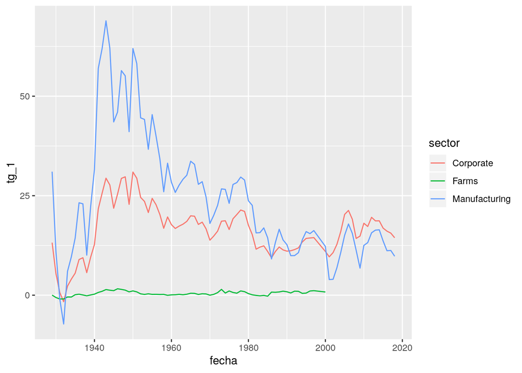

```r
g2 <- rop_rama %>%
  filter(!is.na(tg_1)) %>%
  ggplot(aes(fecha, tg_1, color = sector)) +
  geom_line()
g2
```

# Tasa de Ganancia del capital total

### [Capital Adelantado]

#### [*Stock de capital. Table 1.1. Current-Cost Net Stock of Fixed Assets and Consumer Durable Goods](https://apps.bea.gov/iTable/iTable.cfm?reqid=10&step=3&isuri=1&table_list=16)

Billions of dollars; yearend estimates. Transformado a millones.

```r
stock_total_cc <- read_csv("../data/stock_total_cc.csv",
    skip = 4) %>%
  select(-Line) %>%
  rename(sector = X2) %>%
  na.omit(stock_total_cc) %>%
  gather(.,
           key = fecha,
         value = stock_cc,
         2:95) %>%
  mutate(stock_cc = stock_cc * 1000,
         fecha = as.Date(parse_datetime(fecha, format = "%Y"))) %>%
  select(fecha, everything(.))
stock_total_cc
```

| fecha | sector | stock_cc |
| --- | --- | --- |
| 1925-01-01 | Fixed assets and consumer durable goods | 297500 |
| 1925-01-01 | Fixed assets | 261700 |
| 1925-01-01 | Private | 223400 |
| 1925-01-01 | Nonresidential | 127000 |
| 1925-01-01 | Equipment | 31100 |
| 1925-01-01 | Structures | 94000 |
| 1925-01-01 | Intellectual property products | 1900 |
| 1925-01-01 | Residential | 96400 |
| 1925-01-01 | Government | 38300 |
| 1925-01-01 | Nonresidential | 38300 |

[output cut: 2246 more lines]

### Ganancia

#### [Valor Agregado Neto (Table 1.9.5. Net Value Added by Sector)](https://apps.bea.gov/iTable/iTable.cfm?reqid=19&step=3&isuri=1&nipa_table_list=49&categories=survey)

[Millions of dollars]

Legend/Footnotes 1. Equals net domestic product excluding net value added of households and institutions and of general government. 2. Equals net domestic business value added excluding net farm value added. 3. Equals gross value added of nonprofit institutions excluding consumption of fixed capital on fixed assets owned and used by nonprofit instututions serving households. 4. Equals compensation of general government employees.

```r
net_va <- read_csv("../data/Net Value Added by Sector.csv",
    skip = 4) %>%
  select(-Line) %>%
  rename(sector = X2) %>%
  na.omit(net_va) %>%
  gather(.,
           key = fecha,
         value = net_va_corr,
         2:91) %>%
  mutate(fecha = as.Date(parse_datetime(fecha, format = "%Y"))) %>%
  select(fecha, everything(.))
net_va
```

| fecha | sector | net_va_corr |
| --- | --- | --- |
| 1929-01-01 | Net domestic product | 94148 |
| 1929-01-01 | Business1 | 81788 |
| 1929-01-01 | Nonfarm2 | 73575 |
| 1929-01-01 | Farm | 8213 |
| 1929-01-01 | Households and institutions | 7776 |
| 1929-01-01 | Households | 6474 |
| 1929-01-01 | Nonprofit institutions serving households3 | 1302 |
| 1929-01-01 | General government4 | 4584 |
| 1929-01-01 | Federal | 1053 |
| 1929-01-01 | State and local | 3531 |

[output cut: 890 more lines]

#### Empleo[Table 6.8A. Persons Engaged in Production by Industry](https://apps.bea.gov/iTable/iTable.cfm?reqid=19&step=3&isuri=1&nipa_table_list=206&categories=survey)

In Thousands

Legend/Footnotes 1. sector$Persons engaged in production: Equals the number of full-time equivalent employees plus the number of self-employed persons. Unpaid family workers are not included.

```r
# Carga de bases de distintos años

persons_engaged_29_48 <- read_csv("../data/Persons Engaged in Production by Industry_29_48.csv",
    skip = 4) %>%
  select(-Line) %>%
  rename(sector = X2) %>%
  na.omit(persons_engaged_29_48) %>%
  select(-"1948") %>%
  gather(.,
           key = fecha,
         value = employ,
         2:20) %>%
  mutate(fecha = as.Date(parse_datetime(fecha, format = "%Y")),
         sector = gsub('[[:digit:]]+', '', sector),
         employ = as.double(employ)) %>%
  select(fecha, everything(.))
persons_engaged_48_87 <- read_csv("../data/Persons Engaged in Production by Industry_48_87.csv",
    skip = 4) %>%
  select(-Line) %>%
  rename(sector = X2) %>%
  na.omit(persons_engaged_48_87) %>%
  select(- "1987") %>%
  gather(.,
           key = fecha,
         value = employ,
         2:40) %>%
  mutate(fecha = as.Date(parse_datetime(fecha, format = "%Y")),
         sector = gsub('[[:digit:]]+', '', sector),
         employ = as.double(employ))  %>%
  select(fecha, everything(.))
persons_engaged_87_00 <- read_csv("../data/Persons Engaged in Production by Industry_87_00.csv",
    skip = 4) %>%
  select(-Line) %>%
  rename(sector = X2) %>%
  na.omit(persons_engaged_87_00) %>%
  select(-c("1998","1999", "2000")) %>%
  gather(.,
           key = fecha,
         value = employ,
         2:12) %>%
  mutate(fecha = as.Date(parse_datetime(fecha, format = "%Y")),
         sector = gsub('[[:digit:]]+', '', sector)) %>%
  select(fecha, everything(.))
persons_engaged_98_18 <- read_csv("../data/Persons Engaged in Production by Industry_98_18.csv",
    skip = 4) %>%
  select(-Line) %>%
  rename(sector = X2) %>%
  na.omit(persons_engaged_98_18) %>%
  gather(.,
           key = fecha,
         value = employ,
         2:22) %>%
  mutate(fecha = as.Date(parse_datetime(fecha, format = "%Y")),
         sector = gsub('[[:digit:]]+', '', sector)) %>%
  select(fecha, everything(.))
# Unificación de bases

persons_engaged <- persons_engaged_29_48 %>%
  bind_rows(persons_engaged_48_87) %>%
  bind_rows(persons_engaged_87_00) %>%
  bind_rows(persons_engaged_98_18)

unique(persons_engaged$sector)
```

```
##   [1] "Persons engaged in production"
##   [2] "Domestic industries"
##   [3] "Private industries"
##   [4] "Agriculture, forestry, and fisheries"
##   [5] "Farms"
##   [6] "Agricultural services, forestry, and fisheries"
##   [7] "Mining"
##   [8] "Metal mining"
##   [9] "Anthracite mining"
##  [10] "Bituminous and other soft coal mining"
##  [11] "Crude petroleum and natural gas"
##  [12] "Nonmetallic mining and quarrying"
##  [13] "Contract construction"
##  [14] "Manufacturing"
##  [15] "Durable goods"
```

[output cut: 166 more lines]

Table 6.6A. Wages and Salaries Per Full-Time Equivalent Employee by Industry

https://apps.bea.gov/iTable/iTable.cfm?reqid=19&step=3&isuri=1&nipa_table_list=198&categories=survey

Consumo intermedio

Intermediate Inputs by Industry

https://apps.bea.gov/iTable/iTable.cfm?reqid=51&step=51&isuri=1&table_list=20&series=a

Rotación BEA https://theplanningmotivedotcom.files.wordpress.com/2019/05/academia-turnover-article-pdf.pdf (página 2)

GO: Gross Output by Industry https://apps.bea.gov/iTable/iTable.cfm?reqid=51&step=51&isuri=1&table_list=15&series=a

VA: https://apps.bea.gov/iTable/iTable.cfm?reqid=51&step=51&isuri=1&table_list=1&series=a